# Exploratory Data Analysis Of Instacart Online Store

### Total say By Day

```r
#converting day into Ordered Factor Vector
online_shop$day <- factor(online_shop$day, levels = c("Monday", "Tuesday", "Wednesday", "Thursday", "Friday", "Saturday", "Sunday"))
```

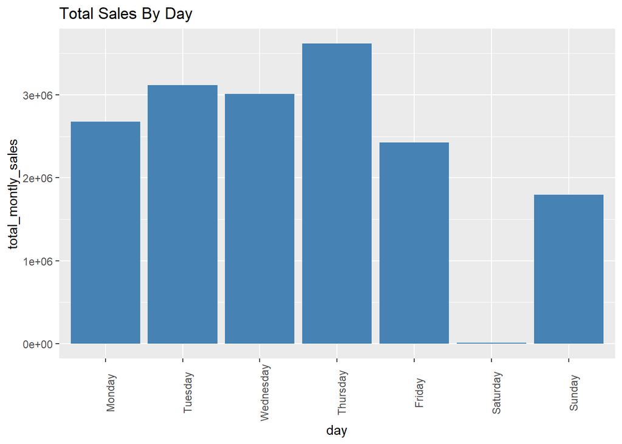

```r
#Total Sales By Day
Total_sales_by_day <-online_shop %>% group_by(day) %>% summarise(total_montly_sales = sum(total_sales)) %>% ggplot(aes(x = day, y = total_montly_sales)) + geom_col( fill = "steelblue")+ theme(axis.text.x = element_text(angle = 90)) + labs(title = "Total Sales By Day ")
Total_sales_by_day
```

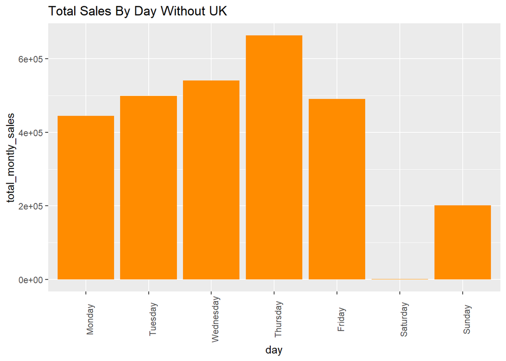

```r
#Total Sales By Day Without UK
Total_sales_by_day_without_uk <-online_shop %>% filter(country != "United Kingdom") %>% group_by(day) %>% summarise(total_montly_sales = sum(total_sales)) %>% ggplot(aes(x = day, y = total_montly_sales)) + geom_col( fill = "darkorange")+ theme(axis.text.x = element_text(angle = 90)) + labs(title = "Total Sales By Day Without UK ")
Total_sales_by_day_without_uk
```

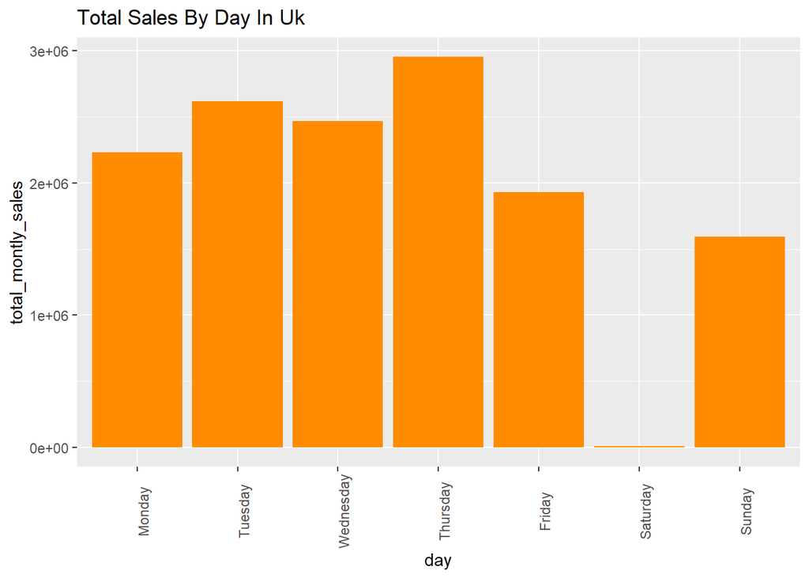

```r
#Total Sales By Day In UK
Total_sales_by_day_in_uk <-online_shop %>% filter(country == "United Kingdom") %>% group_by(day) %>% summarise(total_montly_sales = sum(total_sales)) %>% ggplot(aes(x = day, y = total_montly_sales)) + geom_col( fill = "darkorange")+ theme(axis.text.x = element_text(angle = 90)) + labs(title = "Total Sales By Day In Uk")
Total_sales_by_day_in_uk
```

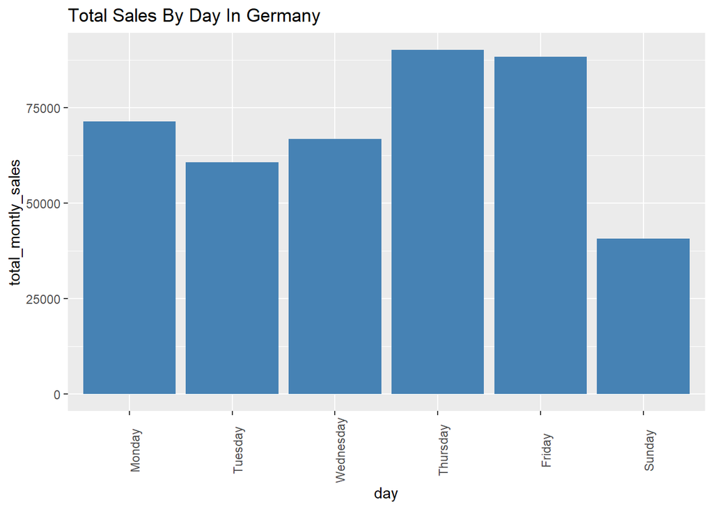

```r
#Total Sales By Day In Germany
Total_sales_by_day_in_germany <-online_shop %>% filter(country == "Germany") %>% group_by(day) %>% summarise(total_montly_sales = sum(total_sales)) %>% ggplot(aes(x = day, y = total_montly_sales)) + geom_col( fill = "steelblue")+ theme(axis.text.x = element_text(angle = 90)) + labs(title = "Total Sales By Day In Germany ")
Total_sales_by_day_in_germany
```

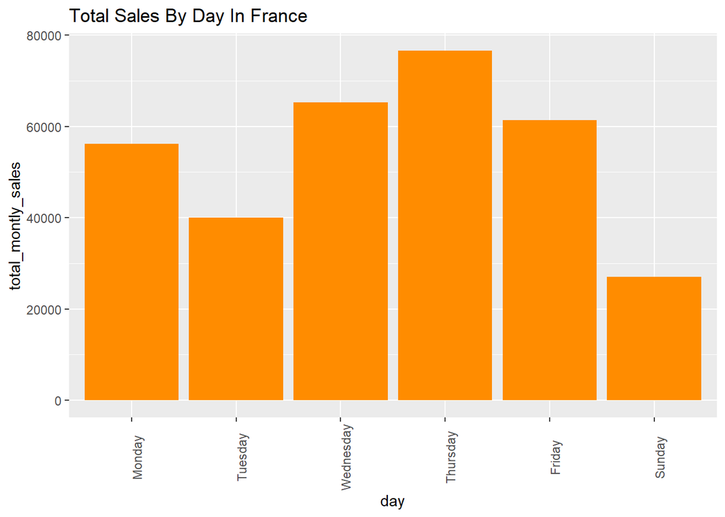

```r
#Total Sales By Day In France
Total_sales_by_day_in_france <-online_shop %>% filter(country == "France") %>% group_by(day) %>% summarise(total_montly_sales = sum(total_sales)) %>% ggplot(aes(x = day, y = total_montly_sales)) + geom_col( fill = "darkorange")+ theme(axis.text.x = element_text(angle = 90)) + labs(title = "Total Sales By Day In France ")
Total_sales_by_day_in_france
```

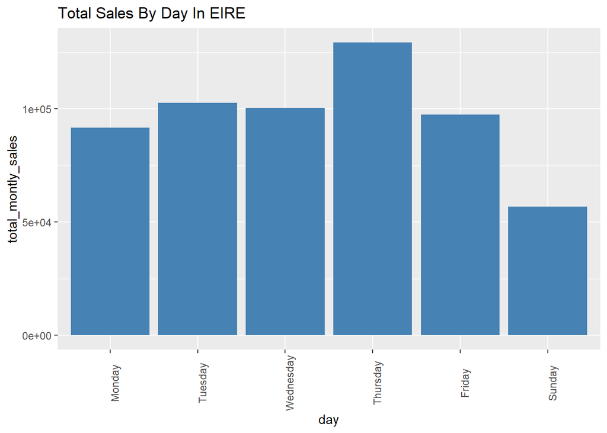

```r
#Total Sales By Day In EIRE
Total_sales_by_day_in_eire <-online_shop %>% filter(country == "EIRE") %>% group_by(day) %>% summarise(total_montly_sales = sum(total_sales)) %>% ggplot(aes(x = day, y = total_montly_sales)) + geom_col( fill = "steelblue")+ theme(axis.text.x = element_text(angle = 90)) + labs(title = "Total Sales By Day In EIRE")
Total_sales_by_day_in_eire
```

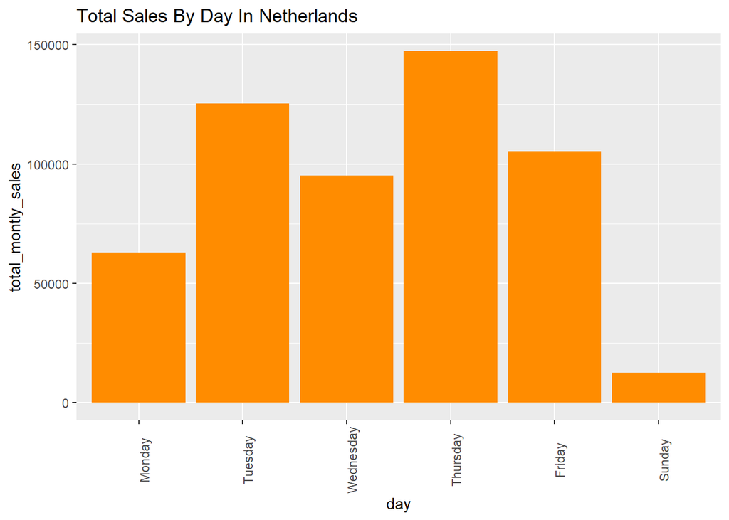

```r
#Total Sales By Day In Netherlands
Total_sales_by_day_in_netherlands <-online_shop %>% filter(country == "Netherlands") %>% group_by(day) %>% summarise(total_montly_sales = sum(total_sales)) %>% ggplot(aes(x = day, y = total_montly_sales)) + geom_col( fill = "darkorange")+ theme(axis.text.x = element_text(angle = 90)) + labs(title = "Total Sales By Day In Netherlands ")
Total_sales_by_day_in_netherlands
```

### Top Customer By Total Sales

```r
#Converting customer_id to factor
online_shop <- online_shop %>% mutate(customer_id = as.factor(customer_id))
```

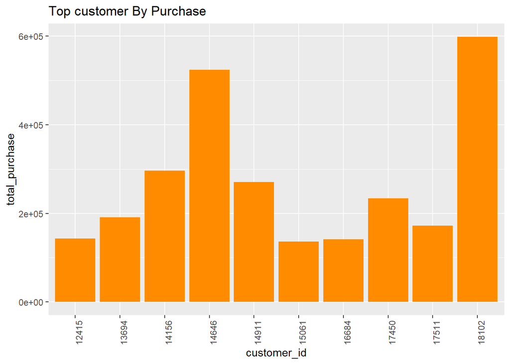

```r
#Top Customer By Total Sales
Top_customer <-online_shop %>% group_by(customer_id) %>%  summarise(total_purchase = sum(total_sales)) %>% arrange(desc(total_purchase)) %>% head(10) %>% ggplot(aes(x = customer_id, y = total_purchase)) + geom_col( fill = "darkorange")+ theme(axis.text.x = element_text(angle = 90)) + labs(title = "Top customer By Purchase")
Top_customer
```

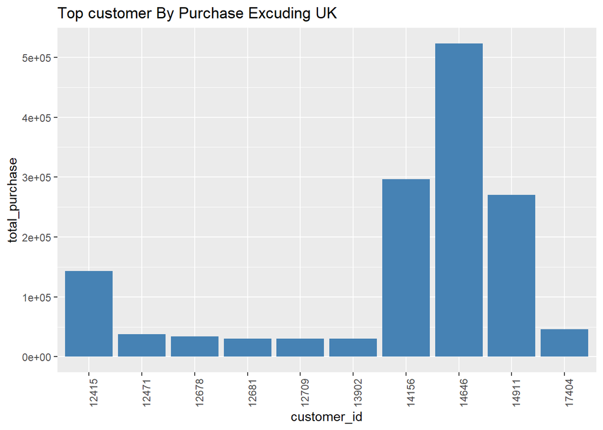

```r
#Top Customer By Total Sales Without UK
Top_customer_without_uk <-online_shop %>% filter(country != "United Kingdom") %>% group_by(customer_id) %>%  summarise(total_purchase = sum(total_sales)) %>% arrange(desc(total_purchase)) %>% head(10) %>% ggplot(aes(x = customer_id, y = total_purchase)) + geom_col( fill = "steelblue")+ theme(axis.text.x = element_text(angle = 90)) + labs(title = "Top customer By Purchase Excuding UK")
Top_customer_without_uk
```

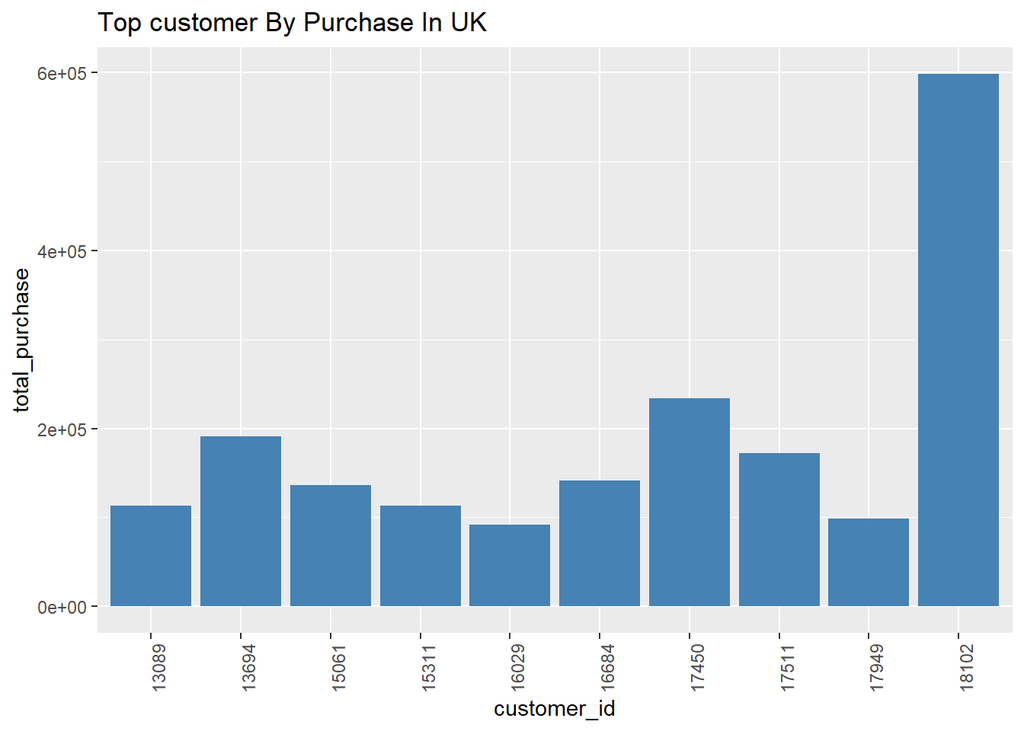

```r
#Top Customer By Total Sales In UK
Top_customer_in_uk <-online_shop %>% filter(country == "United Kingdom") %>% group_by(customer_id) %>%  summarise(total_purchase = sum(total_sales)) %>% arrange(desc(total_purchase)) %>% head(10) %>% ggplot(aes(x = customer_id, y = total_purchase)) + geom_col( fill = "steelblue")+ theme(axis.text.x = element_text(angle = 90)) + labs(title = "Top customer By Purchase In UK")
Top_customer_in_uk
```

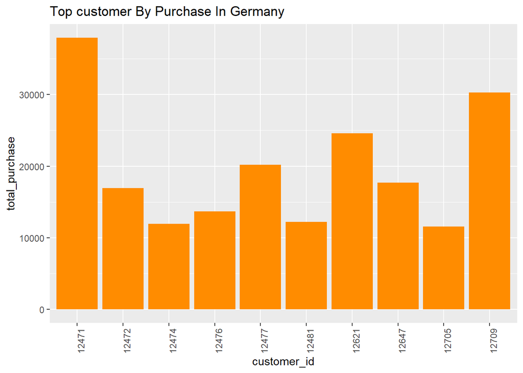

```r
#Top Customer By Total Sales In Germany
Top_customer_in_germany <-online_shop %>% filter(country == "Germany") %>% group_by(customer_id) %>%  summarise(total_purchase = sum(total_sales)) %>% arrange(desc(total_purchase)) %>% head(10) %>% ggplot(aes(x = customer_id, y = total_purchase)) + geom_col( fill = "darkorange")+ theme(axis.text.x = element_text(angle = 90)) + labs(title = "Top customer By Purchase In Germany")
Top_customer_in_germany
```

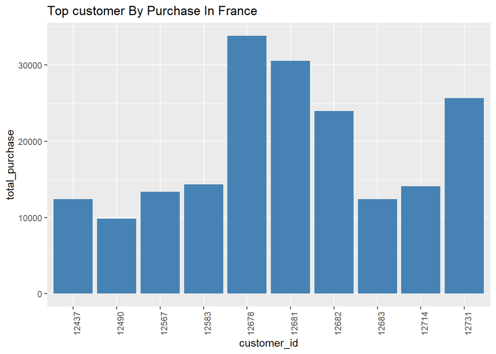

```r
#Top Customer By Total Sales In France
Top_customer_in_france <-online_shop %>% filter(country == "France") %>% group_by(customer_id) %>%  summarise(total_purchase = sum(total_sales)) %>% arrange(desc(total_purchase)) %>% head(10) %>% ggplot(aes(x = customer_id, y = total_purchase)) + geom_col( fill = "steelblue")+ theme(axis.text.x = element_text(angle = 90)) + labs(title = "Top customer By Purchase In France")
Top_customer_in_france
```

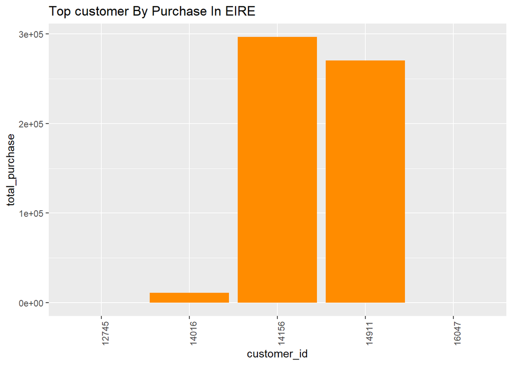

```r
#Top Customer By Total Sales In EIRE
Top_customer_in_eire <-online_shop %>% filter(country == "EIRE") %>% group_by(customer_id) %>%  summarise(total_purchase = sum(total_sales)) %>% arrange(desc(total_purchase)) %>% head(10) %>% ggplot(aes(x = customer_id, y = total_purchase)) + geom_col( fill = "darkorange")+ theme(axis.text.x = element_text(angle = 90))+ labs(title = "Top customer By Purchase In EIRE")
Top_customer_in_eire
```

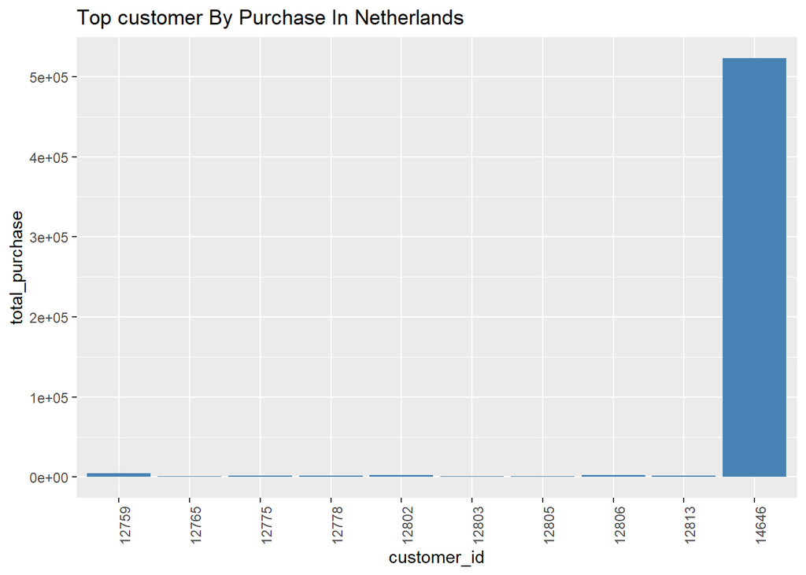

```r
#Top Customer By Total Sales In Netherlands
Top_customer_in_netherlands <-online_shop %>% filter(country == "Netherlands") %>% group_by(customer_id) %>%  summarise(total_purchase = sum(total_sales)) %>% arrange(desc(total_purchase)) %>% head(10) %>% ggplot(aes(x = customer_id, y = total_purchase)) + geom_col( fill = "steelblue")+ theme(axis.text.x = element_text(angle = 90)) + labs(title = "Top customer By Purchase In Netherlands")
Top_customer_in_netherlands
```

## Conclusion

The majority of sales for an online retail come from customers located in the **United Kingdom**. The top five countries with over **5000 sales** per year are the United Kingdom, **Germany**, **EIRE**, **France**, and the **Netherlands**. The products that bring in the **most revenue** may **not** necessarily the ones with the **highest** number of **sales.** Most sales take place between **8 AM** and **4 PM**, with a similar pattern across top 5 countries. There is a **seasonal increase** in sales from **September to December**, with an additional spike in **Eire in January**. The **lowest sales** volume is observed on the weekends, particularly on **Saturdays** and **Sundays**.

### Based on analysis my key recommendation are :

1. Online retail should focus expanding the customer base in the United Kingdom, as it is the top source of sales and revenue.
2. Creating a promotional discount and offer on products which have more sales but generate less profit by to increase profitability.
3. Create a marketing plan to take advantage of peak sales hour (between 8 AM and 4 PM)
4. Creating a Flash sales campaign for weekdays particularly on Saturdays and Sundays to increase sales.

### Future Scope

Further analysis Regression, K-Means Clustering can be done to further enhance the result.

### Share & Act

I feel happy to share this out here, as you are reading this, any suggestion of improvement is highly valuable to me, write me at *mayankmecs@gmail.com*

### Data-driven decision-making

This data analysis follows : Ask - Prepare - Process - Analyze - Share - Act.